# Otus Machine Learning Course. Homework №4

### Воротников Владимир

### Резюме проделанной работы (со ссылками на разделы в документе)

1. EDA & Feature Engineering

Знакомство с данными. Матрица корреляций/heatplot/pairplot. Замена существующих NaN-ов. Преобразование категориальный переменных в числовые (one-hot encoding или уникальные значения в зависимости от смысла переменной). Удаление ненужных столбцов, шкалирование всех переменных в диапазон [0, 1]

2. Basic Clustering

2.1 Modeling

Использование различных алгоритмов кластеризации

2.1.1 K-means

2.1.2 Hierarhical Clustering

Построение дерева. Явной границы не видно, неплохо выглядят варианты с 5-6 кластерами

2.1.3 DBSCAN

Различные варианты параметров. Адекватным кажется 6 кластеров

2.2 Visualizing clusters

Визуализация кластеров после различных методов уменьшения размерности.

2.2.1 PCA

2.2.2 UMAP

2.2.3 tSNE

2.3 Interpretation

Интерпретация результатов показала, что разбиение на кластеры произошло исключительно по булевым переменным (пол, наличие дома в собственности и др.). Для получения менее тривиального результата было решено попробовать альтернативные методы

3. Alternative Clustering

3.1 Modeling with K-Modes

Разделение данных при помощи K-modes решило проблему доминирования категориальных признаков. Данные разделились на 3 кластера.

3.2 Visualizing clusters

3.3 Interpretation

4. Conclusion

В выводе дана интепретация разделения данных на кластеры исходя из предполагаемой бизнес-задачи (таргетирование рекламы)

```python
import numpy as np
import pandas as pd
import seaborn as sns

import matplotlib.pyplot as plt
%matplotlib inline

from sklearn.cluster import KMeans

from IPython.display import display

import warnings
warnings.filterwarnings("ignore")
plt.rcParams["figure.figsize"] = [18, 8]
```

## 1. EDA & Feature Engineering

```python
data = pd.read_csv('data/german_credit_data.csv')
```

```python
data.shape
```

```
(1000, 10)
```

```python
data.head(10)
```

|  | Unnamed: 0 | Age | Sex | Job | Housing | Saving accounts | Checking account | Credit amount | Duration | Purpose |
| --- | --- | --- | --- | --- | --- | --- | --- | --- | --- | --- |
| 0 | 0 | 67 | male | 2 | own | NaN | little | 1169 | 6 | radio/TV |
| 1 | 1 | 22 | female | 2 | own | little | moderate | 5951 | 48 | radio/TV |
| 2 | 2 | 49 | male | 1 | own | little | NaN | 2096 | 12 | education |
| 3 | 3 | 45 | male | 2 | free | little | little | 7882 | 42 | furniture/equipment |
| 4 | 4 | 53 | male | 2 | free | little | little | 4870 | 24 | car |
| 5 | 5 | 35 | male | 1 | free | NaN | NaN | 9055 | 36 | education |
| 6 | 6 | 53 | male | 2 | own | quite rich | NaN | 2835 | 24 | furniture/equipment |
| 7 | 7 | 35 | male | 3 | rent | little | moderate | 6948 | 36 | car |
| 8 | 8 | 61 | male | 1 | own | rich | NaN | 3059 | 12 | radio/TV |
| 9 | 9 | 28 | male | 3 | own | little | moderate | 5234 | 30 | car |

```python
data.drop('Unnamed: 0', axis=1, inplace=True)
```

```python
data.info()
```

```
<class 'pandas.core.frame.DataFrame'>
RangeIndex: 1000 entries, 0 to 999
Data columns (total 9 columns):
 #   Column            Non-Null Count  Dtype
---  ------            --------------  -----
 0   Age               1000 non-null   int64
 1   Sex               1000 non-null   object
 2   Job               1000 non-null   int64
 3   Housing           1000 non-null   object
 4   Saving accounts   817 non-null    object
 5   Checking account  606 non-null    object
 6   Credit amount     1000 non-null   int64
 7   Duration          1000 non-null   int64
 8   Purpose           1000 non-null   object
dtypes: int64(4), object(5)
memory usage: 70.4+ KB
```

```python
data.describe()
```

|  | Age | Job | Credit amount | Duration |
| --- | --- | --- | --- | --- |
| count | 1000.000000 | 1000.000000 | 1000.000000 | 1000.000000 |
| mean | 35.546000 | 1.904000 | 3271.258000 | 20.903000 |
| std | 11.375469 | 0.653614 | 2822.736876 | 12.058814 |
| min | 19.000000 | 0.000000 | 250.000000 | 4.000000 |
| 25% | 27.000000 | 2.000000 | 1365.500000 | 12.000000 |
| 50% | 33.000000 | 2.000000 | 2319.500000 | 18.000000 |
| 75% | 42.000000 | 2.000000 | 3972.250000 | 24.000000 |
| max | 75.000000 | 3.000000 | 18424.000000 | 72.000000 |

```python
data.nunique()
```

```
Age                  53
Sex                   2
Job                   4
Housing               3
Saving accounts       4
Checking account      3
Credit amount       921
Duration             33
Purpose               8
dtype: int64
```

```python
data.isnull().sum()
```

```
Age                   0
Sex                   0
Job                   0
Housing               0
Saving accounts     183
Checking account    394
Credit amount         0
Duration              0
Purpose               0
dtype: int64
```

```python
TO_DROP = []
TO_SCALE = []
```

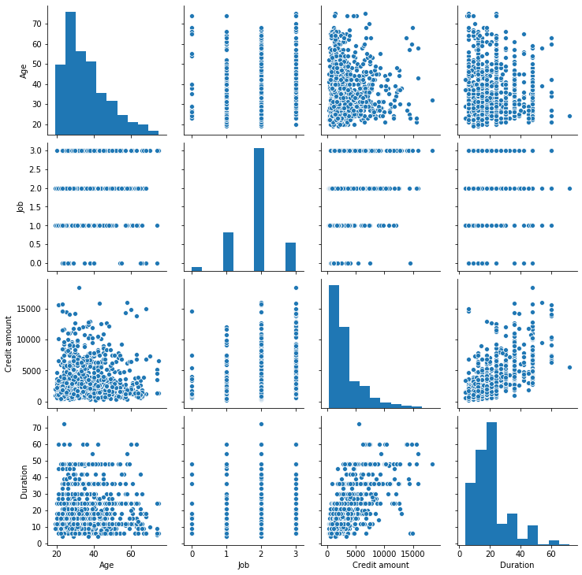

```python
sns.pairplot(data);
```

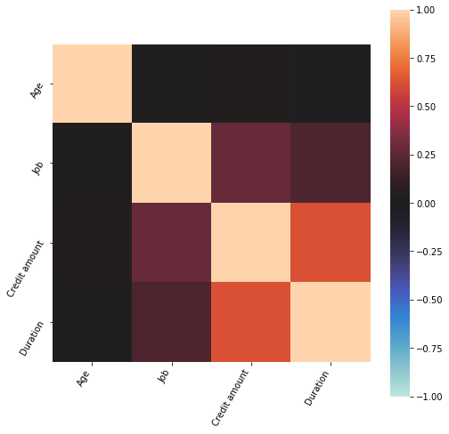

```python
data_corr = data.corr()
# Нарисуем heatmap для матрицы корреляций

fig = plt.figure(figsize=(8,8))
ax = sns.heatmap(
    data_corr,
    vmin=-1, vmax=1, center=0,
    square=True
)
ax.set_xticklabels(
    ax.get_xticklabels(),
    rotation=60,
    horizontalalignment='right'
)
ax.set_yticklabels(
    ax.get_yticklabels(),
    rotation=60,
)
ax.plot();
```

### - Age

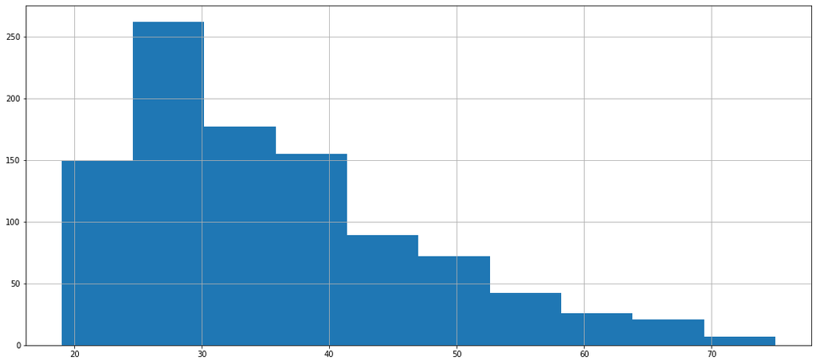

```python
data['Age'].hist();
```

```python
TO_SCALE.append('Age')
```

### - Sex

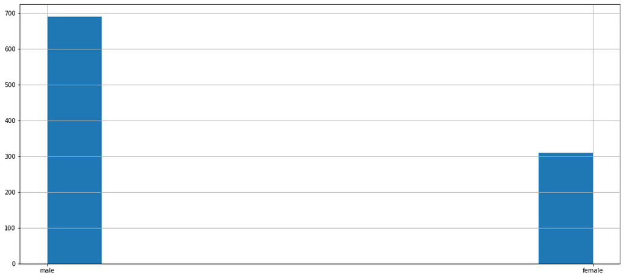

```python
data['Sex'].hist();
```

```python
data['is_male'] = data['Sex']=='male'
data['is_male'] = data['is_male'].astype(int)
TO_DROP.append('Sex')
```

```python
data['is_male'].nunique()
```

```
2
```

### - Job

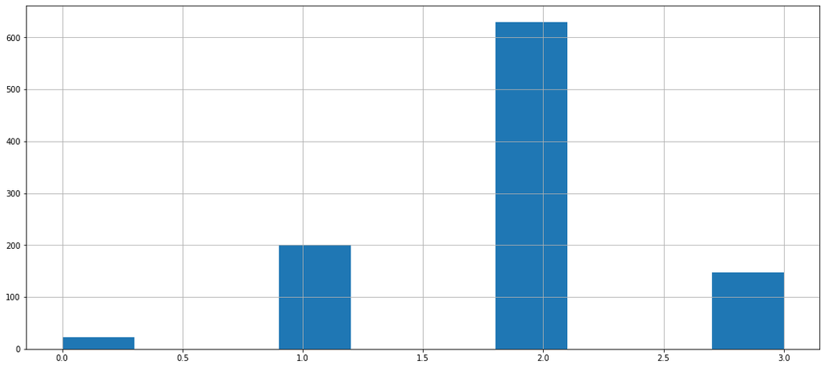

```python
data['Job'].hist();
```

```python
TO_SCALE.append('Job')
```

### - Housing

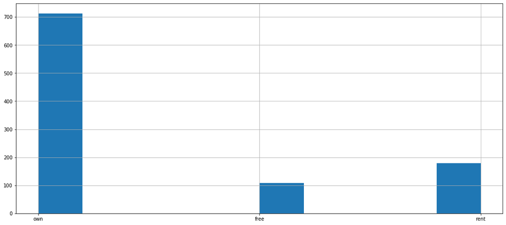

```python
data['Housing'].hist();
```

```python
housing_encoded = pd.get_dummies(data['Housing'], prefix='housing', drop_first=True)
data = pd.concat([data, housing_encoded], axis=1)
TO_DROP.append('Housing')
```

### - Saving accounts

```python
data['Saving accounts'].isnull().sum()
```

```
183
```

```python
data['Saving accounts'] = data['Saving accounts'].fillna('little')
```

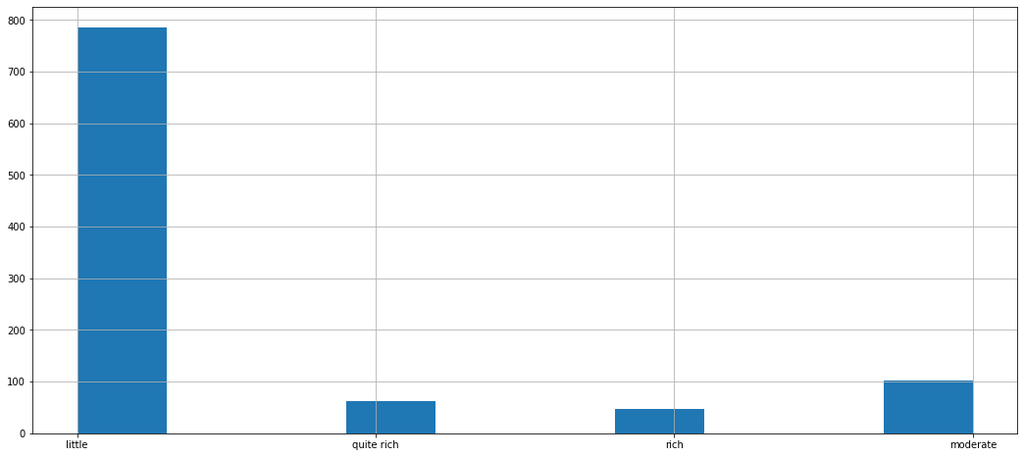

```python
data['Saving accounts'].hist();
```

```python
data['Saving accounts'][data['Saving accounts']=='little'] = 0
data['Saving accounts'][data['Saving accounts']=='moderate'] = 1
data['Saving accounts'][data['Saving accounts']=='quite rich'] = 2
data['Saving accounts'][data['Saving accounts']=='rich'] = 3
```

```python
TO_SCALE.append('Saving accounts')
```

### - Checking account

```python
data['Checking account'].isnull().sum()
```

```
394
```

```python
data['Checking account'].fillna('little', inplace=True)
```

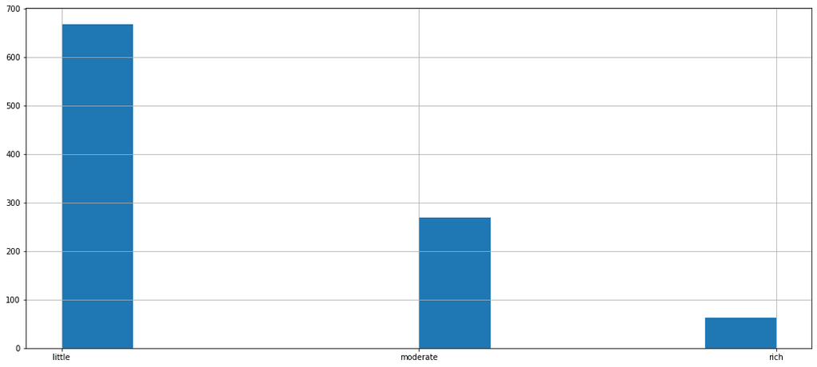

```python
data['Checking account'].hist();
```

```python
data['Checking account'][data['Checking account']=='little'] = 0
data['Checking account'][data['Checking account']=='moderate'] = 1
data['Checking account'][data['Checking account']=='rich'] = 2
```

```python
TO_SCALE.append('Checking account')
```

### - Credit amount

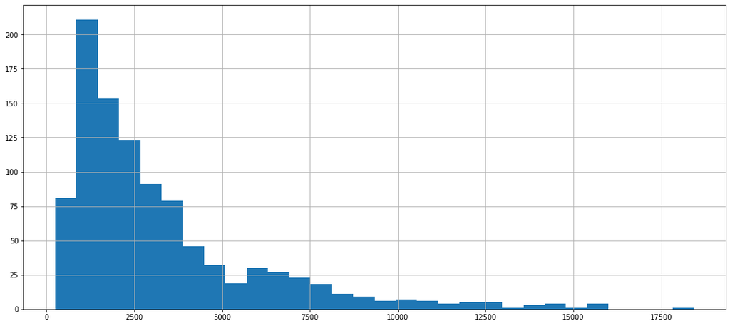

```python
data['Credit amount'].hist(bins=30);
```

```python
data['Credit amount'].describe()
```

```
count     1000.000000
mean      3271.258000
std       2822.736876
min        250.000000
25%       1365.500000
50%       2319.500000
75%       3972.250000
max      18424.000000
Name: Credit amount, dtype: float64
```

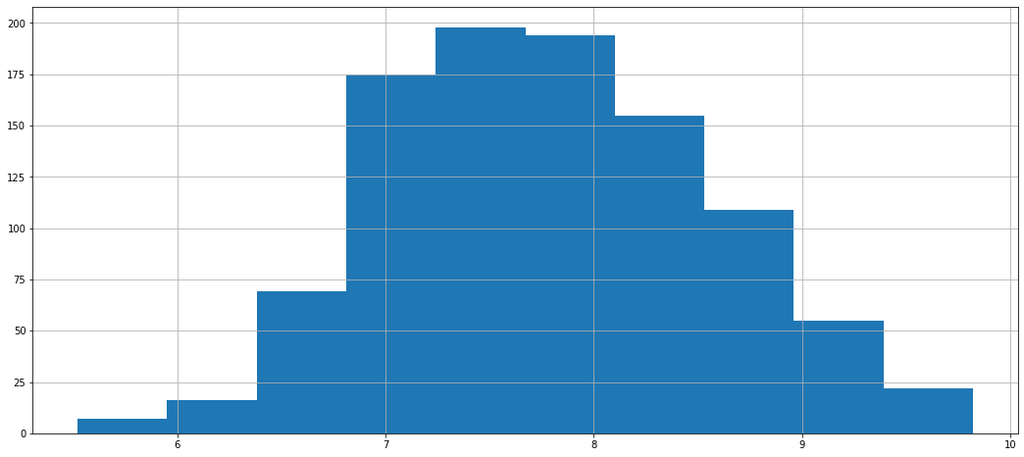

```python
np.log(data['Credit amount']).hist();
```

```python
data['Credit amount'] = np.log(data['Credit amount'])
```

```python
TO_SCALE.append('Credit amount')
```

### - Duration

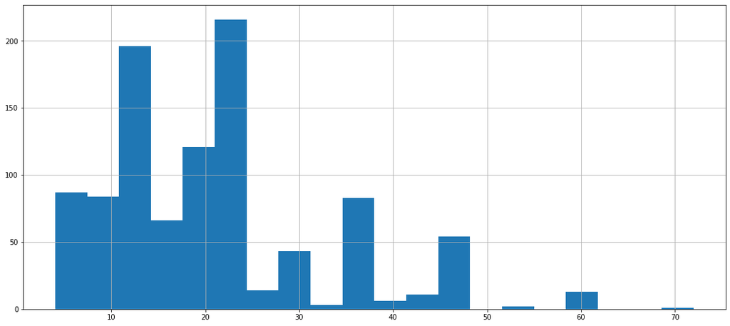

```python
data['Duration'].hist(bins=20);
```

```python
TO_SCALE.append('Duration')
```

### - Purpose

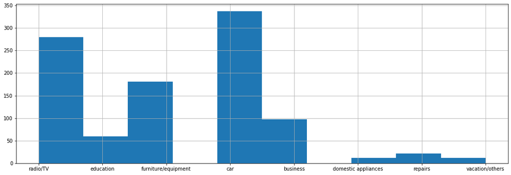

```python
data['Purpose'].hist(figsize=(18,6));
```

```python
data['Purpose'].nunique()
```

```
8
```

```python
data['Purpose'].value_counts()
```

```
car                    337
radio/TV               280
furniture/equipment    181
business                97
education               59
repairs                 22
domestic appliances     12
vacation/others         12
Name: Purpose, dtype: int64
```

```python
data['Purpose'][data['Purpose']=="domestic appliances"] = 'others'
data['Purpose'][data['Purpose']=="vacation/others"] = 'others'
data['Purpose'][data['Purpose']=="repairs"] = 'others'
data['Purpose'][data['Purpose']=="radio/TV"] = 'others'
data['Purpose'][data['Purpose']=="furniture/equipment"] = 'others'
```

```python
purpose_encoded = pd.get_dummies(data['Purpose'], prefix='purpose')
purpose_encoded.drop('purpose_others', axis=1, inplace=True)
data = pd.concat([data, purpose_encoded], axis=1)
TO_DROP.append('Purpose')
```

```python
print(TO_SCALE, TO_DROP)
```

```
['Age', 'Job', 'Saving accounts', 'Checking account', 'Credit amount', 'Duration'] ['Sex', 'Housing', 'Purpose']
```

```python
data.drop(TO_DROP, axis=1, inplace=True)
```

```python
from sklearn.preprocessing import MinMaxScaler

min_max_scaler = MinMaxScaler(feature_range=(0,1))
data[TO_SCALE] = min_max_scaler.fit_transform(data[TO_SCALE])
```

```python
data.head(10)
```

|  | Age | Job | Saving accounts | Checking account | Credit amount | Duration | is_male | housing_own | housing_rent | purpose_business | purpose_car | purpose_education |
| --- | --- | --- | --- | --- | --- | --- | --- | --- | --- | --- | --- | --- |
| 0 | 0.857143 | 0.666667 | 0.000000 | 0.0 | 0.358712 | 0.029412 | 1 | 1 | 0 | 0 | 0 | 0 |
| 1 | 0.053571 | 0.666667 | 0.000000 | 0.5 | 0.737184 | 0.647059 | 0 | 1 | 0 | 0 | 0 | 0 |
| 2 | 0.535714 | 0.333333 | 0.000000 | 0.0 | 0.494500 | 0.117647 | 1 | 1 | 0 | 0 | 0 | 1 |
| 3 | 0.464286 | 0.666667 | 0.000000 | 0.0 | 0.802539 | 0.558824 | 1 | 0 | 0 | 0 | 0 | 0 |
| 4 | 0.607143 | 0.666667 | 0.000000 | 0.0 | 0.690564 | 0.294118 | 1 | 0 | 0 | 0 | 1 | 0 |
| 5 | 0.285714 | 0.333333 | 0.000000 | 0.0 | 0.834803 | 0.470588 | 1 | 0 | 0 | 0 | 0 | 1 |
| 6 | 0.607143 | 0.666667 | 0.666667 | 0.0 | 0.564736 | 0.294118 | 1 | 1 | 0 | 0 | 0 | 0 |
| 7 | 0.285714 | 1.000000 | 0.000000 | 0.5 | 0.773207 | 0.470588 | 1 | 0 | 1 | 0 | 1 | 0 |
| 8 | 0.750000 | 0.333333 | 1.000000 | 0.0 | 0.582421 | 0.117647 | 1 | 1 | 0 | 0 | 0 | 0 |
| 9 | 0.160714 | 1.000000 | 0.000000 | 0.5 | 0.707327 | 0.382353 | 1 | 1 | 0 | 0 | 1 | 0 |

```python
data.describe()
```

|  | Age | Job | Saving accounts | Checking account | Credit amount | Duration | is_male | housing_own | housing_rent | purpose_business | purpose_car | purpose_education |
| --- | --- | --- | --- | --- | --- | --- | --- | --- | --- | --- | --- | --- |
| count | 1000.000000 | 1000.000000 | 1000.000000 | 1000.000000 | 1000.000000 | 1000.000000 | 1000.000000 | 1000.000000 | 1000.000000 | 1000.000000 | 1000.000000 | 1000.000000 |
| mean | 0.295464 | 0.634667 | 0.124333 | 0.197500 | 0.527269 | 0.248574 | 0.690000 | 0.713000 | 0.179000 | 0.097000 | 0.337000 | 0.059000 |
| std | 0.203133 | 0.217871 | 0.268436 | 0.302217 | 0.180578 | 0.177336 | 0.462725 | 0.452588 | 0.383544 | 0.296106 | 0.472921 | 0.235743 |
| min | 0.000000 | 0.000000 | 0.000000 | 0.000000 | 0.000000 | 0.000000 | 0.000000 | 0.000000 | 0.000000 | 0.000000 | 0.000000 | 0.000000 |
| 25% | 0.142857 | 0.666667 | 0.000000 | 0.000000 | 0.394845 | 0.117647 | 0.000000 | 0.000000 | 0.000000 | 0.000000 | 0.000000 | 0.000000 |
| 50% | 0.250000 | 0.666667 | 0.000000 | 0.000000 | 0.518063 | 0.205882 | 1.000000 | 1.000000 | 0.000000 | 0.000000 | 0.000000 | 0.000000 |
| 75% | 0.410714 | 0.666667 | 0.000000 | 0.500000 | 0.643177 | 0.294118 | 1.000000 | 1.000000 | 0.000000 | 0.000000 | 1.000000 | 0.000000 |
| max | 1.000000 | 1.000000 | 1.000000 | 1.000000 | 1.000000 | 1.000000 | 1.000000 | 1.000000 | 1.000000 | 1.000000 | 1.000000 | 1.000000 |

## 2. Basic Clustering

### 2.1 Modeling

### 2.1.1 K-means

```python
from sklearn.cluster import KMeans
import matplotlib.ticker as ticker
```

```python
data_r = data.iloc[:,:9].copy(deep=True)
```

```python
data_r.shape
```

```
(1000, 9)
```

```python
from sklearn.metrics import silhouette_score
inertia = []
silhouette = []
k = range(1, 30)
for k_i in k:
    km = KMeans(n_clusters=k_i, n_jobs=-1).fit(data_r)
    inertia.append(km.inertia_)
    if k_i>1:
        silhouette.append(silhouette_score(data_r, km.labels_))
```

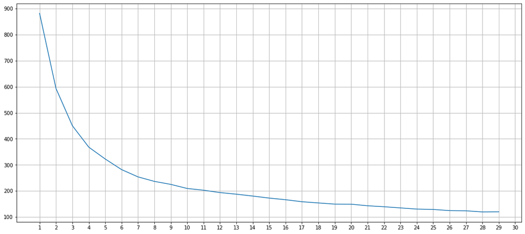

```python
fig, ax = plt.subplots()
ax.plot(k, inertia)
start, end = ax.get_xlim()
ax.xaxis.set_ticks(np.arange(1, end, 1))
ax.grid()
plt.show()
```

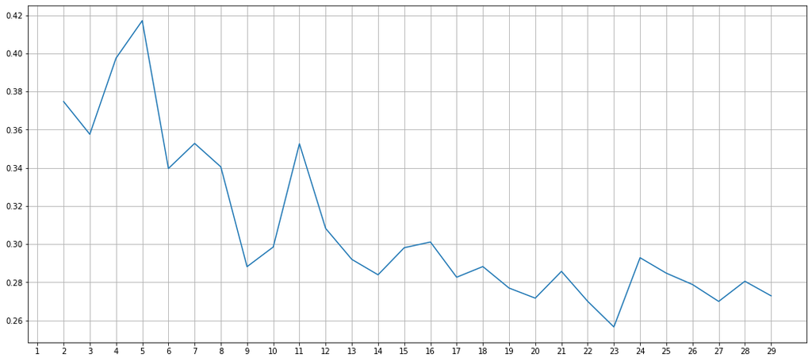

```python
fig, ax = plt.subplots()
k = range(2, 30)
ax.plot(k, silhouette)
ax.xaxis.set_ticks(np.arange(1, 30, 1))
ax.grid()
plt.show()
```

### 2.1.2 Hierarhical

```python
from sklearn.cluster import AgglomerativeClustering
from scipy.cluster.hierarchy import dendrogram, linkage

Z = linkage(data_r, method='centroid', metric='euclidean')
```

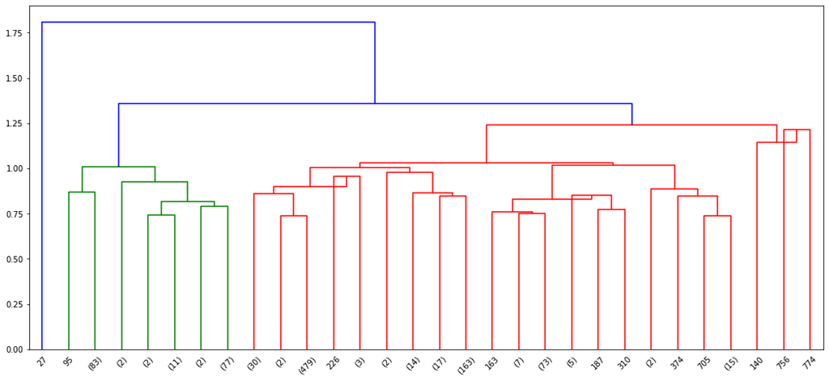

```python
fig, ax = plt.subplots(1, 1)
dend = dendrogram(Z, ax=ax, truncate_mode='lastp')
```

```python
clustering = AgglomerativeClustering().fit(data_r)
```

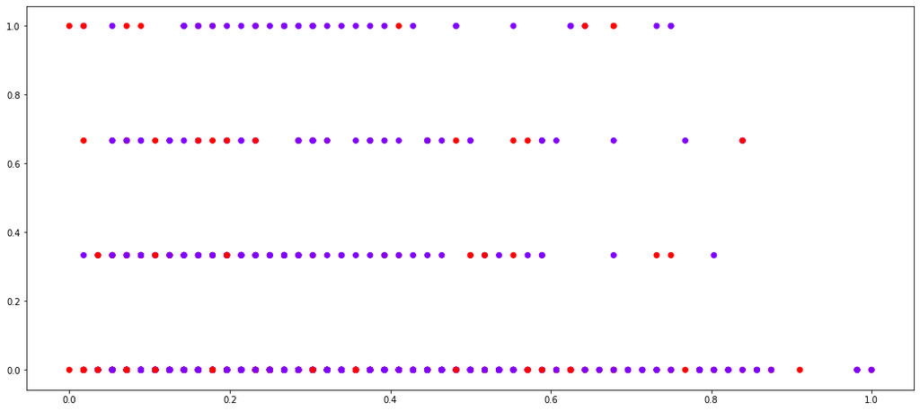

```python
plt.scatter(data_r.iloc[:,0],data_r.iloc[:,2], c=clustering.labels_, cmap='rainbow')
```

### 2.1.3 DBSCAN

```python
from sklearn.cluster import DBSCAN
```

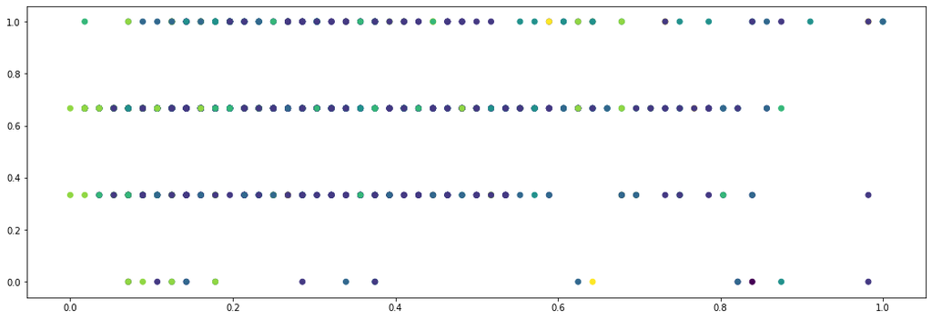

```python
def dbscan_demo(eps=0.5, min_pts=1, metric='euclidean'):
    dbscan = DBSCAN(eps=eps, min_samples=min_pts).fit(data_r)
    labels = dbscan.labels_
    plt.figure(figsize=(18, 6))
    plt.scatter(data_r.iloc[:, 0], data_r.iloc[:, 1], c=labels)
    return dbscan


# dbs = dbscan_demo(0.75,10)
dbs = dbscan_demo(0.75,10,"cosine")
```

```python
len(dbs.labels_), dbs.labels_.max()
```

```
(1000, 5)
```

### 2.2 Visualizing clusters

### 2.2.1 PCA

```python
from sklearn.decomposition import PCA

pca = PCA(n_components=2)
principalComponents = pca.fit_transform(data_r)
principalDf = pd.DataFrame(data = principalComponents,
                           columns = ['principal component 1',
                                      'principal component 2'])
dbs_labels = pd.Series(dbs.labels_, name='target')
finalDf = pd.concat([principalDf, dbs_labels], axis=1)
```

```python
finalDf.head(5)
```

|  | principal component 1 | principal component 2 | target |
| --- | --- | --- | --- |
| 0 | -0.456912 | -0.173988 | 0 |
| 1 | -0.038904 | 0.738396 | 1 |
| 2 | -0.437294 | -0.147177 | 0 |
| 3 | 0.275993 | -0.573690 | 2 |
| 4 | 0.267451 | -0.558775 | 2 |

```python
dbs_labels.value_counts()
```

```
 0    517
 1    196
 4     95
 2     88
 3     84
 5     19
-1      1
Name: target, dtype: int64
```

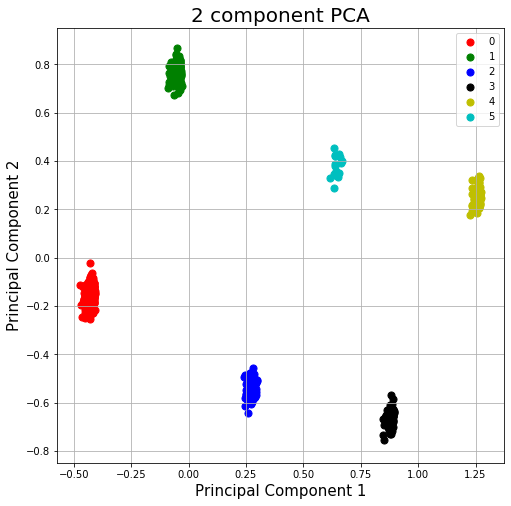

```python
fig = plt.figure(figsize = (8,8))
ax = fig.add_subplot(1,1,1)
ax.set_xlabel('Principal Component 1', fontsize = 15)
ax.set_ylabel('Principal Component 2', fontsize = 15)
ax.set_title('2 component PCA', fontsize = 20)
targets = [0, 1, 2, 3, 4, 5]
colors = ['r', 'g', 'b', 'k', 'y', 'c']
for target, color in zip(targets,colors):
    indicesToKeep = finalDf['target'] == target
    ax.scatter(finalDf.loc[indicesToKeep, 'principal component 1']
               , finalDf.loc[indicesToKeep, 'principal component 2']
               , c = color
               , s = 50)
ax.legend(targets)
ax.grid()
```

### 2.2.2 UMAP

```python
import umap
import umap.plot
```

```python
mapper = umap.UMAP().fit(data_r)
```

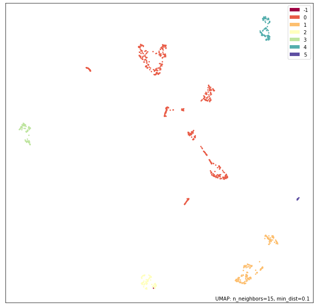

```python
umap.plot.points(mapper, labels=dbs_labels)
```

### 2.2.3 tSNE

```python
from sklearn.manifold import TSNE
tsne = TSNE(n_components=2, verbose=1, perplexity=40, n_iter=300)
tsne_results = tsne.fit_transform(data_r)
```

```
[t-SNE] Computing 121 nearest neighbors...
[t-SNE] Indexed 1000 samples in 0.002s...
[t-SNE] Computed neighbors for 1000 samples in 0.034s...
[t-SNE] Computed conditional probabilities for sample 1000 / 1000
[t-SNE] Mean sigma: 0.217523
[t-SNE] KL divergence after 250 iterations with early exaggeration: 50.833347
[t-SNE] KL divergence after 300 iterations: 0.443057
```

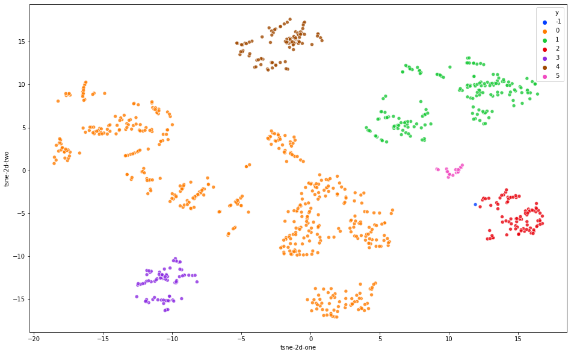

```python
df_subset = pd.DataFrame()
df_subset['tsne-2d-one'] = tsne_results[:,0]
df_subset['tsne-2d-two'] = tsne_results[:,1]
df_subset['y'] = dbs_labels

plt.figure(figsize=(16,10))
sns.scatterplot(
    x="tsne-2d-one", y="tsne-2d-two",
    hue="y",
    palette=sns.color_palette("bright", 7),
    data=df_subset,
    legend="full",
    alpha=0.8
)
```

## 2.3 Interpretation

```python
data_basic = data.copy(deep=True)
data_basic['cluster_number'] = dbs_labels
```

```python
data_basic[data_basic['cluster_number']==-1]
```

|  | Age | Job | Saving accounts | Checking account | Credit amount | Duration | is_male | housing_own | housing_rent | purpose_business | purpose_car | purpose_education | cluster_number |
| --- | --- | --- | --- | --- | --- | --- | --- | --- | --- | --- | --- | --- | --- |
| 774 | 0.839286 | 0.0 | 0.666667 | 1.0 | 0.413572 | 0.117647 | 1 | 0 | 0 | 0 | 1 | 0 | -1 |

```python
data_basic.drop([774], axis=0, inplace=True)
```

```python
data_basic.groupby('cluster_number').size()
```

```
cluster_number
0    517
1    196
2     88
3     84
4     95
5     19
dtype: int64
```

```python
data_basic.groupby('cluster_number').mean()
```

| cluster_number | Age | Job | Saving accounts | Checking account | Credit amount | Duration | is_male | housing_own | housing_rent | purpose_business | purpose_car | purpose_education |
| --- | --- | --- | --- | --- | --- | --- | --- | --- | --- | --- | --- | --- |
| 0 | 0.309340 | 0.632495 | 0.130239 | 0.195358 | 0.526832 | 0.246388 | 1 | 1.0 | 0.0 | 0.123791 | 0.321083 | 0.036750 |
| 1 | 0.261935 | 0.610544 | 0.119048 | 0.214286 | 0.479002 | 0.223589 | 0 | 1.0 | 0.0 | 0.061224 | 0.270408 | 0.076531 |
| 2 | 0.422078 | 0.731061 | 0.075758 | 0.176136 | 0.622758 | 0.363302 | 1 | 0.0 | 0.0 | 0.045455 | 0.511364 | 0.125000 |
| 3 | 0.251701 | 0.638889 | 0.111111 | 0.202381 | 0.547309 | 0.222864 | 1 | 0.0 | 1.0 | 0.119048 | 0.369048 | 0.059524 |
| 4 | 0.159962 | 0.596491 | 0.157895 | 0.157895 | 0.503646 | 0.225232 | 0 | 0.0 | 1.0 | 0.063158 | 0.336842 | 0.052632 |
| 5 | 0.519737 | 0.701754 | 0.105263 | 0.315789 | 0.630307 | 0.271672 | 0 | 0.0 | 0.0 | 0.052632 | 0.473684 | 0.210526 |

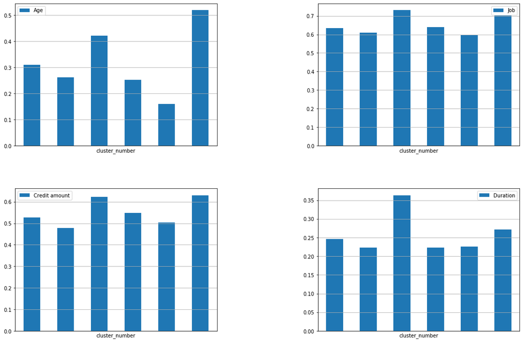

```python
fig = plt.figure(figsize=(18,12))

ax_list = []
for a in range(1,5):
    ax_list.append(fig.add_subplot(2, 2, a))

plt.subplots_adjust(wspace=0.5, hspace=0.3)
curr_ax=0

for i in ['Age', 'Job', 'Credit amount', 'Duration']:
    data_basic.groupby('cluster_number')[i].mean().plot.bar(grid=True,
                                                            ax=ax_list[curr_ax],
                                                            xticks=[]).legend()
    curr_ax += 1
```

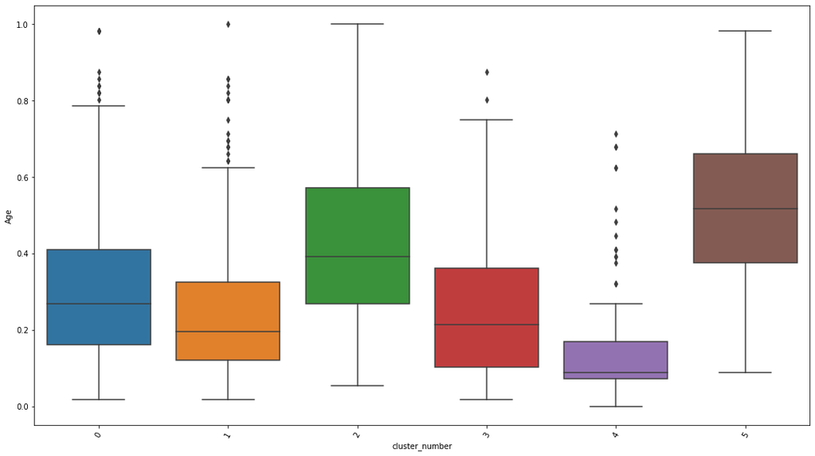

```python
plt.figure(figsize=(18,10))
sns.boxplot(x='cluster_number', y='Age', data=data_basic)
plt.xticks(rotation=60);
```

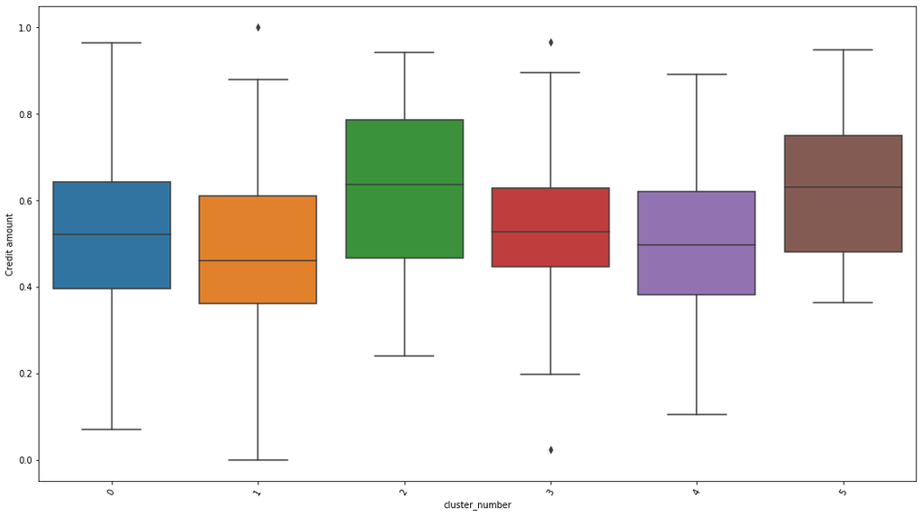

```python
plt.figure(figsize=(18,10))
sns.boxplot(x='cluster_number', y='Credit amount', data=data_basic)
plt.xticks(rotation=60);
```

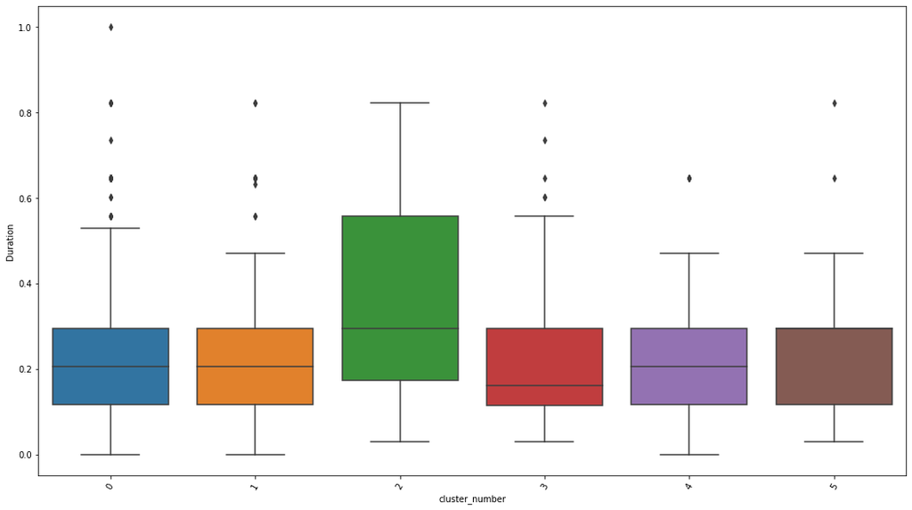

```python
plt.figure(figsize=(18,10))
sns.boxplot(x='cluster_number', y='Duration', data=data_basic)
plt.xticks(rotation=60);
```

По следующему выводу:

```python
data_basic.groupby('cluster_number').mean()
```

| cluster_number | Age | Job | Saving accounts | Checking account | Credit amount | Duration | is_male | housing_own | housing_rent | purpose_business | purpose_car | purpose_education |
| --- | --- | --- | --- | --- | --- | --- | --- | --- | --- | --- | --- | --- |
| 0 | 0.309340 | 0.632495 | 0.130239 | 0.195358 | 0.526832 | 0.246388 | 1 | 1.0 | 0.0 | 0.123791 | 0.321083 | 0.036750 |
| 1 | 0.261935 | 0.610544 | 0.119048 | 0.214286 | 0.479002 | 0.223589 | 0 | 1.0 | 0.0 | 0.061224 | 0.270408 | 0.076531 |
| 2 | 0.422078 | 0.731061 | 0.075758 | 0.176136 | 0.622758 | 0.363302 | 1 | 0.0 | 0.0 | 0.045455 | 0.511364 | 0.125000 |
| 3 | 0.251701 | 0.638889 | 0.111111 | 0.202381 | 0.547309 | 0.222864 | 1 | 0.0 | 1.0 | 0.119048 | 0.369048 | 0.059524 |
| 4 | 0.159962 | 0.596491 | 0.157895 | 0.157895 | 0.503646 | 0.225232 | 0 | 0.0 | 1.0 | 0.063158 | 0.336842 | 0.052632 |
| 5 | 0.519737 | 0.701754 | 0.105263 | 0.315789 | 0.630307 | 0.271672 | 0 | 0.0 | 0.0 | 0.052632 | 0.473684 | 0.210526 |

или, например:

```python
data_basic[data_basic['cluster_number']==0].housing_rent.nunique()
```

```
1
```

видно, что разделение произошло строго по 3 булевым переменным (is_male, housing_own, housing_rent).

Т.е. было получено тривиальное (но это не значит, что плохое) разделение, которое можно было легко получить и без использования алгоритмов кластеризации.

Далее предлагается попробовать использовать другой метод (K-modes) для работы с категориальными данными

## 3. Alternative Clustering

### 3.1 Modeling with K-Modes

```python
from kmodes.kmodes import KModes
```

```python
data_adv = data.copy(deep=True)
```

```python
from sklearn.metrics import silhouette_score
silhouette = []
k = range(1, 30)
for k_i in k:
    km = KModes(n_clusters=k_i, n_jobs=-1, init="Cao", n_init=30, max_iter=500).fit(data_adv)
    if k_i>1:
        silhouette.append(silhouette_score(data_adv, km.labels_))
```

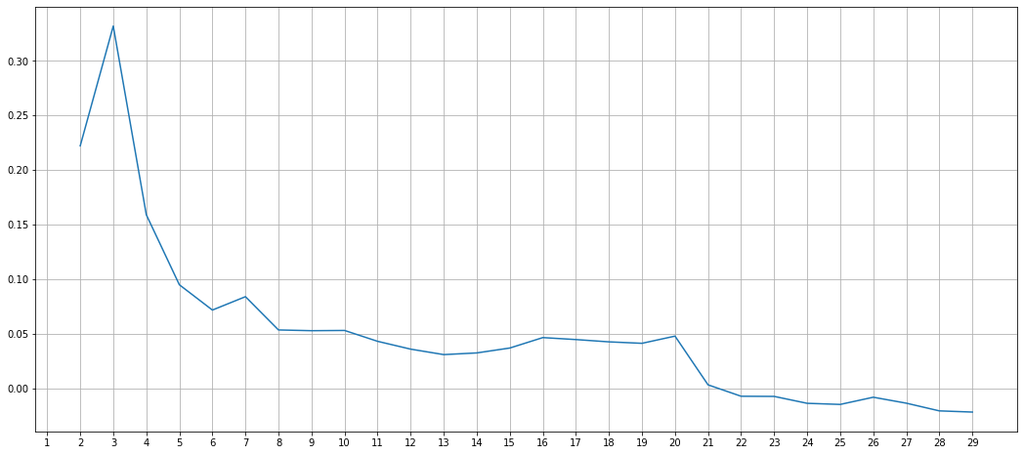

```python
fig, ax = plt.subplots()
k = range(2, 30)
ax.plot(k, silhouette)
ax.xaxis.set_ticks(np.arange(1, 30, 1))
ax.grid()
plt.show()
```

```python
km = KModes(n_clusters=3, n_jobs=-1).fit(data_adv)
```

### 3.2 Visualizing clusters

```python
pca = PCA(n_components=2)
principalComponents = pca.fit_transform(data_adv)
principalDf = pd.DataFrame(data = principalComponents,
                           columns = ['principal component 1',
                                      'principal component 2'])
km_labels = pd.Series(km.labels_, name='target')
finalDf = pd.concat([principalDf, km_labels], axis=1)
```

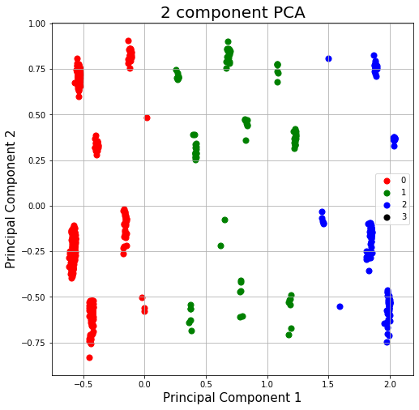

```python
fig = plt.figure(figsize = (8,8))
ax = fig.add_subplot(1,1,1)
ax.set_xlabel('Principal Component 1', fontsize = 15)
ax.set_ylabel('Principal Component 2', fontsize = 15)
ax.set_title('2 component PCA', fontsize = 20)
targets = [0, 1, 2, 3]
colors = ['r', 'g', 'b', 'k']
for target, color in zip(targets,colors):
    indicesToKeep = finalDf['target'] == target
    ax.scatter(finalDf.loc[indicesToKeep, 'principal component 1']
               , finalDf.loc[indicesToKeep, 'principal component 2']
               , c = color
               , s = 50)
ax.legend(targets)
ax.grid()
```

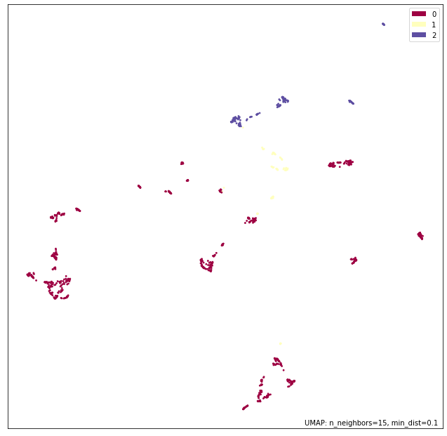

```python
mapper = umap.UMAP().fit(data_adv)
umap.plot.points(mapper, labels=km_labels)
```

```python
tsne = TSNE(n_components=2, verbose=1, perplexity=40, n_iter=300)
tsne_results = tsne.fit_transform(data_adv)
```

```
[t-SNE] Computing 121 nearest neighbors...
[t-SNE] Indexed 1000 samples in 0.002s...
[t-SNE] Computed neighbors for 1000 samples in 0.039s...
[t-SNE] Computed conditional probabilities for sample 1000 / 1000
[t-SNE] Mean sigma: 0.316469
[t-SNE] KL divergence after 250 iterations with early exaggeration: 52.597191
[t-SNE] KL divergence after 300 iterations: 0.388825
```

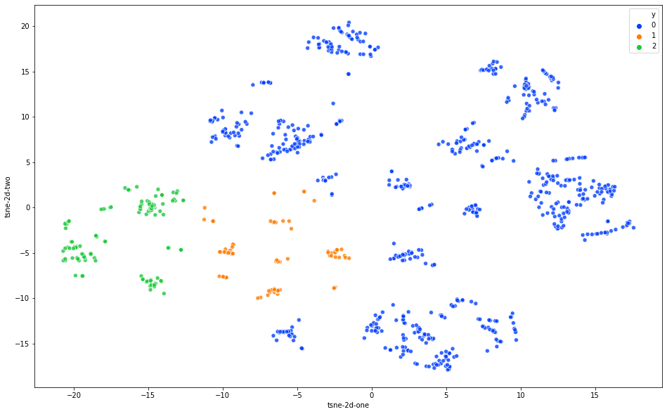

```python
df_subset = pd.DataFrame()
df_subset['tsne-2d-one'] = tsne_results[:,0]
df_subset['tsne-2d-two'] = tsne_results[:,1]
df_subset['y'] = km.labels_

plt.figure(figsize=(16,10))
sns.scatterplot(
    x="tsne-2d-one", y="tsne-2d-two",
    hue="y",
    palette=sns.color_palette("bright", 3),
    data=df_subset,
    legend="full",
    alpha=0.8
)
```

### 3.3 Interpretation

```python
data_adv['cluster_number'] = km.labels_
```

```python
data_adv.groupby('cluster_number').mean()
```

| cluster_number | Age | Job | Saving accounts | Checking account | Credit amount | Duration | is_male | housing_own | housing_rent | purpose_business | purpose_car | purpose_education |
| --- | --- | --- | --- | --- | --- | --- | --- | --- | --- | --- | --- | --- |
| 0 | 0.307205 | 0.623829 | 0.121374 | 0.187416 | 0.519270 | 0.248386 | 0.764391 | 0.910308 | 0.000000 | 0.105756 | 0.294511 | 0.060241 |
| 1 | 0.336006 | 0.741497 | 0.132653 | 0.372449 | 0.612861 | 0.303421 | 0.357143 | 0.336735 | 0.316327 | 0.030612 | 0.785714 | 0.040816 |
| 2 | 0.213249 | 0.619355 | 0.133333 | 0.135484 | 0.511706 | 0.214801 | 0.541935 | 0.000000 | 0.954839 | 0.096774 | 0.258065 | 0.064516 |

```python
data_adv['cluster_number'].value_counts()
```

```
0    747
2    155
1     98
Name: cluster_number, dtype: int64
```

```python
data_adv.columns[:-1]
```

```
Index(['Age', 'Job', 'Saving accounts', 'Checking account', 'Credit amount',
       'Duration', 'is_male', 'housing_own', 'housing_rent',
       'purpose_business', 'purpose_car', 'purpose_education'],
      dtype='object')
```

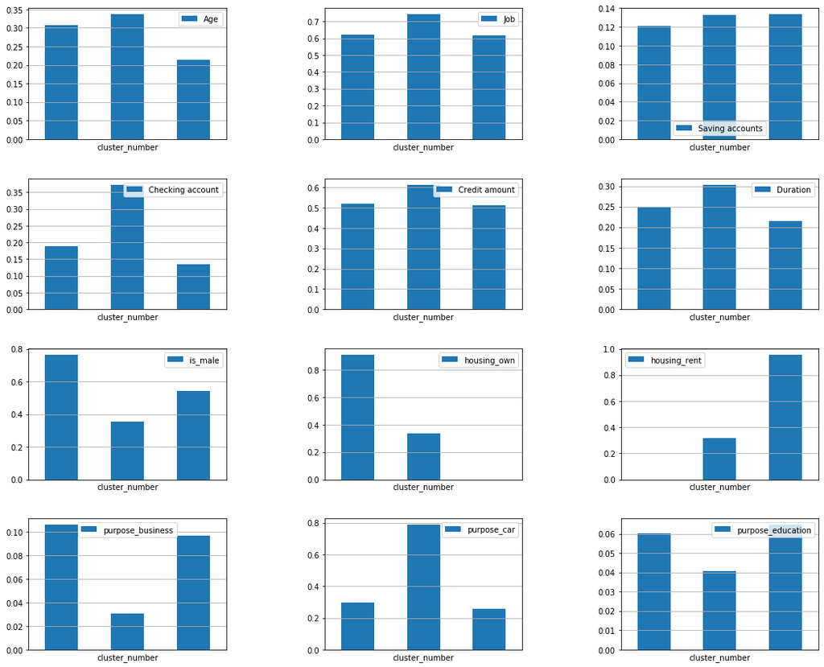

```python
fig = plt.figure(figsize=(18,15))

ax_list = []
for a in range(1,13):
    ax_list.append(fig.add_subplot(4, 3, a))

plt.subplots_adjust(wspace=0.5, hspace=0.3)
curr_ax=0

for i in data_adv.columns[:-1]:
    data_adv.groupby('cluster_number')[i].mean().plot.bar(grid=True,
                                                            ax=ax_list[curr_ax],
                                                            xticks=[]).legend()
    curr_ax += 1
```

```python
data = pd.read_csv('data/german_credit_data.csv')
data.drop('Unnamed: 0', axis=1, inplace=True)
data['cluster_number'] = km.labels_
```

```python
data.groupby('cluster_number').mean()
```

| cluster_number | Age | Job | Credit amount | Duration |
| --- | --- | --- | --- | --- |
| 0 | 36.203481 | 1.871486 | 3136.188755 | 20.890228 |
| 1 | 37.816327 | 2.224490 | 4909.428571 | 24.632653 |
| 2 | 30.941935 | 1.858065 | 2886.458065 | 18.606452 |

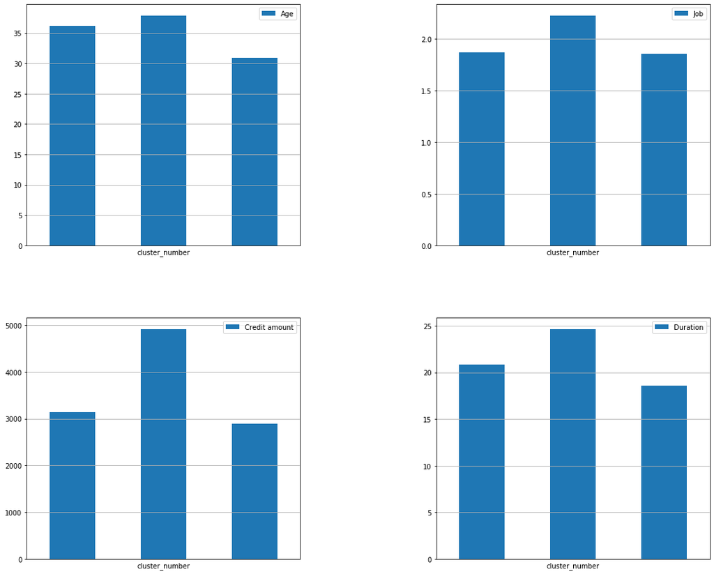

```python
fig = plt.figure(figsize=(18,15))

ax_list = []
for a in range(1,5):
    ax_list.append(fig.add_subplot(2, 2, a))

plt.subplots_adjust(wspace=0.5, hspace=0.3)
curr_ax=0

for i in ['Age', 'Job', 'Credit amount', 'Duration']:
    data.groupby('cluster_number')[i].mean().plot.bar(grid=True,
                                                            ax=ax_list[curr_ax],
                                                            xticks=[]).legend()
    curr_ax += 1
```

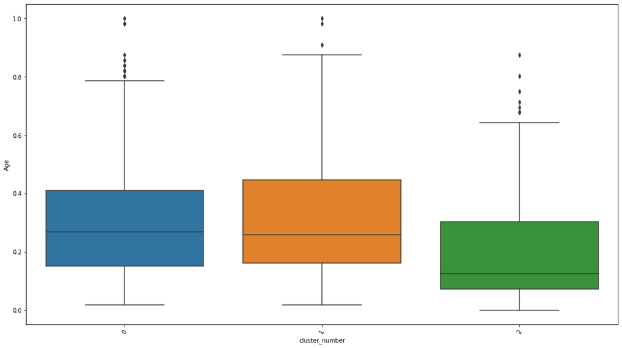

```python
plt.figure(figsize=(18,10))
sns.boxplot(x='cluster_number', y='Age', data=data_adv)
# sns.boxplot(x=data_adv, hue=data_adv['cluster_number'])
plt.xticks(rotation=60);
```

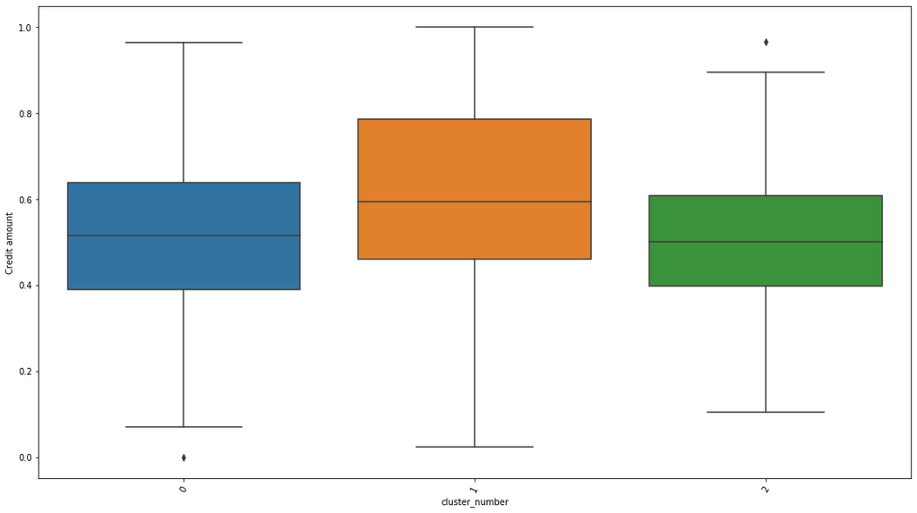

```python
plt.figure(figsize=(18,10))
sns.boxplot(x='cluster_number', y='Credit amount', data=data_adv)
plt.xticks(rotation=60);
```

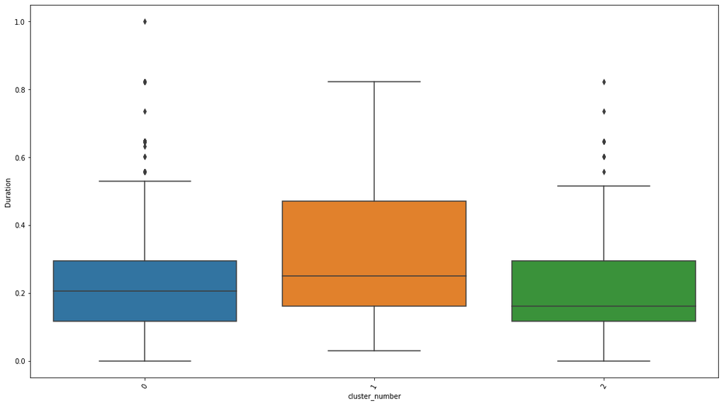

```python
plt.figure(figsize=(18,10))
sns.boxplot(x='cluster_number', y='Duration', data=data_adv)
plt.xticks(rotation=60);
```

```python
y = data_adv.cluster_number
x = data_adv.drop(['cluster_number'], axis = 1 )

# # Разбиваем при печати на два диапазона для наглядности
x_1 = pd.concat([y,x.iloc[:,0:7]],axis=1)
x_2 = pd.concat([y,x.iloc[:,7:]],axis=1)
x_1 = pd.melt(x_1,id_vars="cluster_number",
                    var_name="features",
                    value_name='value')
x_2 = pd.melt(x_2,id_vars="cluster_number",
                    var_name="features",
                    value_name='value')
```

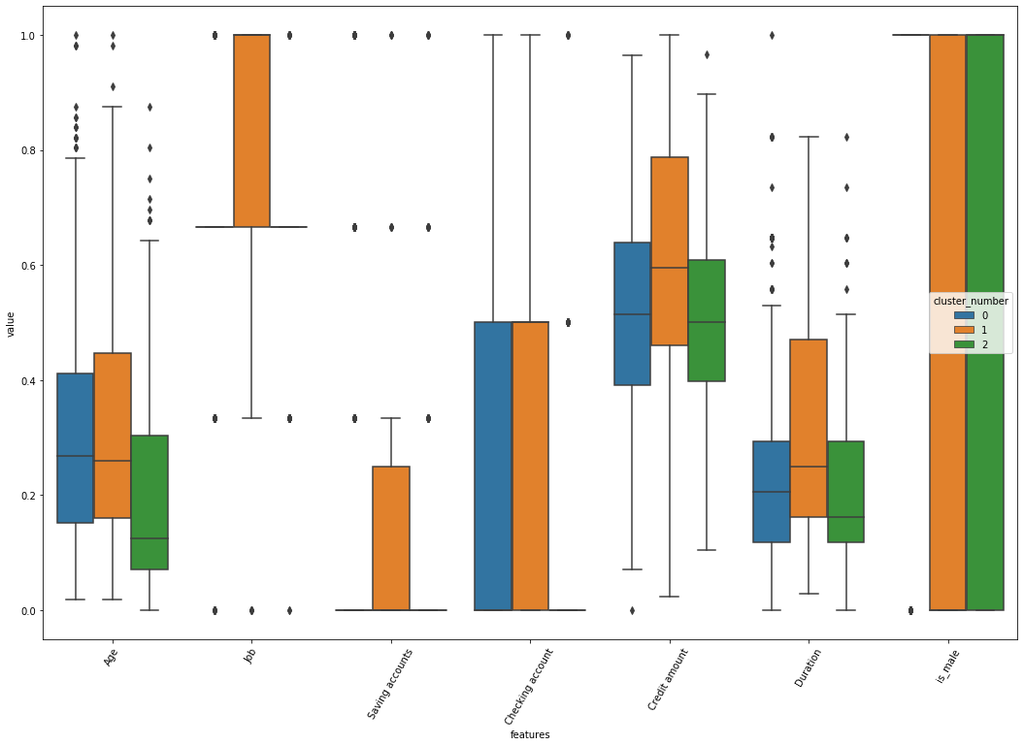

```python
plt.figure(figsize=(18,12))
sns.boxplot(x="features", y="value", hue="cluster_number", data=x_1)
plt.xticks(rotation=60);
```

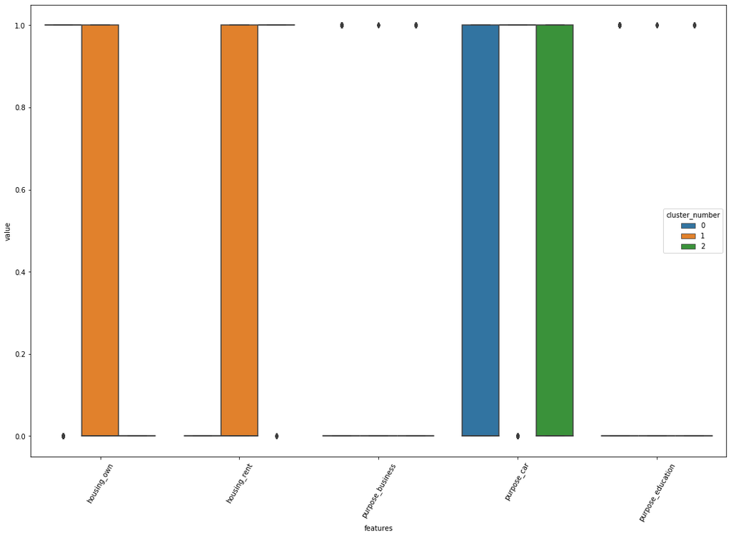

```python
plt.figure(figsize=(18,12))
sns.boxplot(x="features", y="value", hue="cluster_number", data=x_2)
plt.xticks(rotation=60);
```

## 4. Conclusion

Результат разбиения на кластеры с помощью K-modes показался более интересным.

В результате деления получается 3 кластера. Их можно интерпретировать следующим образом:

Кластер №0: Люди среднего возраста с собственным домом, преимущественно мужчины.

Кластер №1: Люди с возрастом немного выше среднего, имеющие большой кредит, преимущественно на автомобиль.

Кластер №2: Люди младшего возраста, не имеющие в собственности недвижость.

Если считать основной задачей кластеризации последующую таргетированную рекламу, то можно сказать, что для разных кластеров подойдет разная реклама, а именно:

Кластер №0: страхование жилья, пенсионные программы, кредиты для бизнеса

Кластер №1: автострахование, пенсионные программы, ипотечные программы

Кластер №2: кредиты на обучение, автокредиты, ипотечные программы

В зависимости от конечно бизнес-задачи, количество кластеров и способ их разбиения может измениться